# Dexamethasone response in airway smooth muscle cells

Bulk RNA-seq differential expression with DESeq2

Author

Tiphaine Cayol

Published

August 5, 2026

## Overview

Differential expression analysis of the *airway* dataset: 4 human airway smooth muscle cell lines, each with a paired untreated and dexamethasone-treated sample (Himes et al. 2014, PMID 24926665).

The design is **paired by donor cell line** — each line supplies its own control — so the model blocks on `cellLine` and tests `treatment`:

$$\text{design} = \sim \text{cellLine} + \text{treatment}$$

```r
library(DESeq2)
library(tidyverse)
library(pheatmap)
library(ggrepel)
library(RColorBrewer)

set.seed(42)

knitr::opts_chunk$set(dev = "png", dpi = 150)

# Resolve the repo root whether this is rendered from the repo root or from analysis/.
# Avoids a dependency on {here} while keeping paths correct either way.
repo_root <- if (file.exists("data/experiment_table.csv")) "." else ".."
stopifnot(file.exists(file.path(repo_root, "data", "experiment_table.csv")))

fig_dir <- file.path(repo_root, "results", "figures")
dir.create(fig_dir, recursive = TRUE, showWarnings = FALSE)

ALPHA <- 0.05  # FDR threshold, used consistently throughout
```

## Load inputs

The count matrix carries a `transcript_id(s)` column alongside `gene_id`; both are dropped from the numeric matrix, with `gene_id` retained as rownames.

```r
counts_raw <- read_tsv(
  file.path(repo_root, "data", "rsem.merged.gene_counts.tsv"),
  show_col_types = FALSE
)

coldata <- read_csv(
  file.path(repo_root, "data", "experiment_table.csv"),
  show_col_types = FALSE
)

gene_ids <- counts_raw$gene_id
stopifnot(!anyDuplicated(gene_ids))  # rownames must be unique

counts <- counts_raw |>
  select(-gene_id, -`transcript_id(s)`) |>
  as.matrix()
rownames(counts) <- gene_ids

cat(sprintf("Loaded %d genes x %d samples\n", nrow(counts), ncol(counts)))
```

```
Loaded 58735 genes x 8 samples
```

```r
knitr::kable(coldata, caption = "Sample sheet")
```

Sample sheet

| ID | cellLine | treatment |
| --- | --- | --- |
| SRR1039508 | N61311 | Untreated |
| SRR1039509 | N61311 | Dexamethasone |
| SRR1039512 | N052611 | Untreated |
| SRR1039513 | N052611 | Dexamethasone |
| SRR1039516 | N080611 | Untreated |
| SRR1039517 | N080611 | Dexamethasone |
| SRR1039520 | N061011 | Untreated |
| SRR1039521 | N061011 | Dexamethasone |

## Round non-integer counts

RSEM apportions multi-mapping reads probabilistically, so counts are **estimates, not integers** — 11,117 genes carry fractional values here. DESeq2 requires integers and errors otherwise.

`round()` is used deliberately rather than `floor()`, `trunc()`, or `as.integer()`: those truncate downward and would bias low-count genes toward zero.

```r
n_fractional <- sum(apply(counts, 1, function(x) any(x != floor(x))))
zeros_before <- sum(rowSums(counts) == 0)

counts <- round(counts)
storage.mode(counts) <- "integer"  # DESeq2 wants an integer matrix

zeros_after <- sum(rowSums(counts) == 0)

cat(sprintf(
  "Genes with fractional counts: %s\nAll-zero genes before rounding: %s\nAll-zero genes after rounding:  %s\n",
  format(n_fractional, big.mark = ","),
  format(zeros_before, big.mark = ","),
  format(zeros_after, big.mark = ",")
))
```

```
Genes with fractional counts: 11,117
All-zero genes before rounding: 28,344
All-zero genes after rounding:  28,501
```

Note the all-zero count *rises* after rounding — genes whose every value sat below 0.5 collapse to zero. This is why filtering must happen **after** rounding, never before.

## Align samples to the sample sheet

Column order happens to match the sample sheet in this file, but relying on that is how silently-wrong results happen. Subset by name and assert.

```r
counts <- counts[, coldata$ID]
stopifnot(identical(colnames(counts), coldata$ID))

cat("Counts columns and sample sheet rows correspond by name.\n")
```

```
Counts columns and sample sheet rows correspond by name.
```

## Factors and reference level

R orders factor levels alphabetically, which would make `Dexamethasone` the reference and **invert the sign of every log2 fold change**. Setting `Untreated` explicitly means a positive LFC reads as “induced by dexamethasone”.

```r
# read_csv returns a tibble, which has no real rownames. DESeq2 matches colData rows to
# count columns by rowname, and pheatmap needs them for annotations, so make it a
# base data.frame keyed by sample ID.
coldata <- as.data.frame(coldata)
rownames(coldata) <- coldata$ID

coldata$treatment <- relevel(factor(coldata$treatment), ref = "Untreated")
coldata$cellLine  <- factor(coldata$cellLine)

cat("treatment levels:", paste(levels(coldata$treatment), collapse = " -> "), "\n")
```

```
treatment levels: Untreated -> Dexamethasone
```

```r
cat("cellLine levels: ", paste(levels(coldata$cellLine), collapse = ", "), "\n")
```

```
cellLine levels:  N052611, N061011, N080611, N61311
```

```r
stopifnot(levels(coldata$treatment)[1] == "Untreated")
```

The first level printed above is the reference. `Untreated` must appear first.

## Pre-filter low-count genes

Nearly half of all genes are zero across every sample. Keeping genes with at least 10 counts in at least 4 samples (4 = the smallest group size) drops uninformative genes, which improves the dispersion fit and reduces the multiple-testing burden.

```r
n_before <- nrow(counts)
keep <- rowSums(counts >= 10) >= 4
counts <- counts[keep, ]

cat(sprintf(
  "Genes before filtering: %s\nGenes after filtering:  %s (%.1f%% retained)\n",
  format(n_before, big.mark = ","),
  format(nrow(counts), big.mark = ","),
  100 * nrow(counts) / n_before
))
```

```
Genes before filtering: 58,735
Genes after filtering:  15,478 (26.4% retained)
```

## Build the DESeqDataSet and fit

```r
dds <- DESeqDataSetFromMatrix(
  countData = counts,
  colData   = coldata,
  design    = ~ cellLine + treatment
)

dds <- DESeq(dds)

resultsNames(dds)
```

```
[1] "Intercept"
[2] "cellLine_N061011_vs_N052611"
[3] "cellLine_N080611_vs_N052611"
[4] "cellLine_N61311_vs_N052611"
[5] "treatment_Dexamethasone_vs_Untreated"
```

`treatment_Dexamethasone_vs_Untreated` is the coefficient of interest; the `cellLine_*` terms absorb donor-to-donor baseline differences and are not interpreted.

## Quality control

### Library sizes

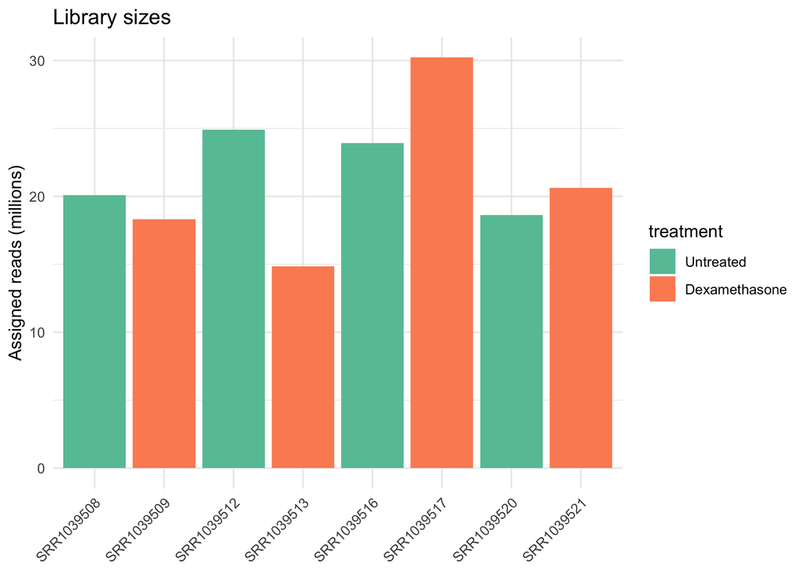

```r
libsize <- tibble(
  ID       = colnames(dds),
  total    = colSums(counts(dds)),
  treatment = colData(dds)$treatment,
  cellLine  = colData(dds)$cellLine
)

p_lib <- ggplot(libsize, aes(x = ID, y = total / 1e6, fill = treatment)) +
  geom_col() +
  scale_fill_brewer(palette = "Set2") +
  labs(x = NULL, y = "Assigned reads (millions)", title = "Library sizes") +
  theme_minimal() +
  theme(axis.text.x = element_text(angle = 45, hjust = 1))

p_lib
```

```r
ggsave(file.path(fig_dir, "library_sizes.png"), p_lib, width = 7, height = 4.5, dpi = 150)
```

Library sizes span roughly a two-fold range, which is why raw counts are never compared directly — DESeq2’s size factors handle this.

### PCA

Variance-stabilised counts, computed blind to the design so QC stays independent of the model being tested.

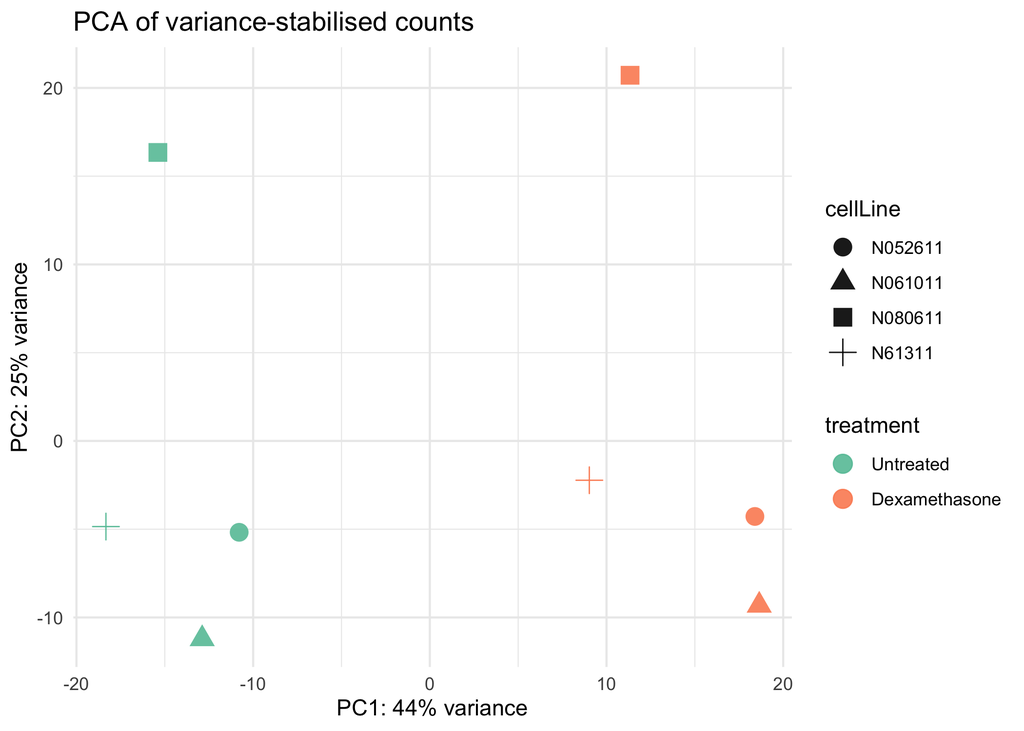

```r
vsd <- vst(dds, blind = TRUE)

pca_data <- plotPCA(vsd, intgroup = c("treatment", "cellLine"), returnData = TRUE)
pct_var <- round(100 * attr(pca_data, "percentVar"))

p_pca <- ggplot(pca_data, aes(PC1, PC2, colour = treatment, shape = cellLine)) +
  geom_point(size = 4, alpha = 0.9) +
  scale_colour_brewer(palette = "Set2") +
  labs(
    x = paste0("PC1: ", pct_var[1], "% variance"),
    y = paste0("PC2: ", pct_var[2], "% variance"),
    title = "PCA of variance-stabilised counts"
  ) +
  theme_minimal()

p_pca
```

```r
ggsave(file.path(fig_dir, "pca.png"), p_pca, width = 7, height = 5, dpi = 150)
```

### Sample-to-sample distances

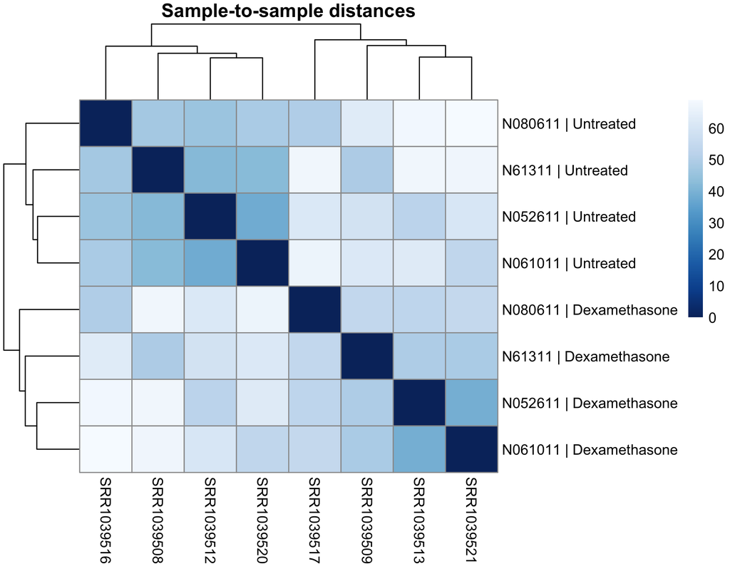

```r
sample_dists <- dist(t(assay(vsd)))
dist_matrix <- as.matrix(sample_dists)
rownames(dist_matrix) <- paste(colData(vsd)$cellLine, colData(vsd)$treatment, sep = " | ")
colnames(dist_matrix) <- colnames(vsd)

dist_args <- list(
  mat = dist_matrix,
  clustering_distance_rows = sample_dists,
  clustering_distance_cols = sample_dists,
  color = colorRampPalette(rev(brewer.pal(9, "Blues")))(255),
  main = "Sample-to-sample distances"
)

do.call(pheatmap, dist_args)
```

```r
# pheatmap writes files via its own `filename` argument; a manual png()/dev.off()
# wrapper does not capture its grid output reliably.
invisible(do.call(pheatmap, c(
  dist_args,
  list(filename = file.path(fig_dir, "sample_distances.png"), width = 7, height = 5.5)
)))
```

## Differential expression results

Two versions are kept deliberately: **unshrunk** effect sizes for the statistics, and **shrunk** effect sizes for ranking and plotting. Shrinkage pulls in the noisy fold changes of low-count genes without touching p-values.

```r
res <- results(
  dds,
  contrast = c("treatment", "Dexamethasone", "Untreated"),
  alpha = ALPHA
)

# apeglm is the preferred shrinkage estimator; degrade gracefully if it is absent
# so a missing optional package cannot fail the render.
shrink_type <- if (requireNamespace("apeglm", quietly = TRUE)) "apeglm" else "normal"
if (shrink_type == "normal") {
  message("apeglm not installed - falling back to type = 'normal' shrinkage.")
}

res_shrunk <- lfcShrink(
  dds,
  coef = "treatment_Dexamethasone_vs_Untreated",
  type = shrink_type
)

summary(res)
```

```
out of 15478 with nonzero total read count
adjusted p-value < 0.05
LFC > 0 (up)       : 2189, 14%
LFC < 0 (down)     : 1761, 11%
outliers [1]       : 0, 0%
low counts [2]     : 301, 1.9%
(mean count < 11)
[1] see 'cooksCutoff' argument of ?results
[2] see 'independentFiltering' argument of ?results
```

```r
n_sig  <- sum(res$padj < ALPHA, na.rm = TRUE)
n_up   <- sum(res$padj < ALPHA & res$log2FoldChange > 0, na.rm = TRUE)
n_down <- sum(res$padj < ALPHA & res$log2FoldChange < 0, na.rm = TRUE)

cat(sprintf(
  "At FDR < %.2f: %s genes differentially expressed (%s up, %s down) out of %s tested.\nShrinkage estimator: %s\n",
  ALPHA,
  format(n_sig, big.mark = ","), format(n_up, big.mark = ","),
  format(n_down, big.mark = ","), format(sum(!is.na(res$padj)), big.mark = ","),
  shrink_type
))
```

```
At FDR < 0.05: 3,950 genes differentially expressed (2,189 up, 1,761 down) out of 15,177 tested.
Shrinkage estimator: apeglm
```

### Annotate with gene symbols

The matrix carries Ensembl IDs only. `org.Hs.eg.db` maps them offline, keeping the report reproducible; if it is unavailable the analysis proceeds on Ensembl IDs alone.

```r
res_df <- as.data.frame(res) |>
  rownames_to_column("gene_id") |>
  mutate(log2FoldChange_shrunk = res_shrunk$log2FoldChange[match(gene_id, rownames(res_shrunk))])

if (requireNamespace("org.Hs.eg.db", quietly = TRUE)) {
  res_df$symbol <- AnnotationDbi::mapIds(
    org.Hs.eg.db::org.Hs.eg.db,
    keys      = res_df$gene_id,
    keytype   = "ENSEMBL",
    column    = "SYMBOL",
    multiVals = "first"
  )
  cat(sprintf("Mapped symbols for %s of %s genes.\n",
              format(sum(!is.na(res_df$symbol)), big.mark = ","),
              format(nrow(res_df), big.mark = ",")))
} else {
  res_df$symbol <- NA_character_
  message("org.Hs.eg.db not installed - results reported with Ensembl IDs only.")
}
```

```
Mapped symbols for 13,931 of 15,478 genes.
```

```r
# Label preferring symbol, falling back to Ensembl ID
res_df <- res_df |>
  mutate(label = coalesce(symbol, gene_id)) |>
  arrange(padj)
```

### Top differentially expressed genes

```r
res_df |>
  slice_head(n = 25) |>
  select(gene_id, symbol, baseMean, log2FoldChange, log2FoldChange_shrunk, pvalue, padj) |>
  mutate(
    baseMean = round(baseMean, 1),
    across(starts_with("log2FoldChange"), \(x) round(x, 3)),
    # p-values span many orders of magnitude; scientific notation keeps them readable
    across(c(pvalue, padj), \(x) format(x, scientific = TRUE, digits = 3))
  ) |>
  knitr::kable(caption = "Top 25 genes by adjusted p-value")
```

Top 25 genes by adjusted p-value

| gene_id | symbol | baseMean | log2FoldChange | log2FoldChange_shrunk | pvalue | padj |
| --- | --- | --- | --- | --- | --- | --- |
| ENSG00000152583 | SPARCL1 | 968.9 | 4.575 | 4.556 | 2.16e-138 | 3.28e-134 |
| ENSG00000165995 | CACNB2 | 519.9 | 3.315 | 3.305 | 1.41e-133 | 1.07e-129 |
| ENSG00000120129 | DUSP1 | 3207.6 | 2.945 | 2.935 | 8.42e-130 | 4.26e-126 |
| ENSG00000101347 | SAMHD1 | 13641.7 | 3.754 | 3.741 | 5.75e-124 | 2.18e-120 |
| ENSG00000189221 | MAOA | 2273.8 | 3.344 | 3.329 | 8.56e-122 | 2.60e-118 |
| ENSG00000162614 | NEXN | 5191.7 | 2.024 | 2.012 | 2.41e-117 | 6.11e-114 |
| ENSG00000157214 | STEAP2 | 2824.9 | 1.971 | 1.959 | 3.69e-117 | 8.01e-114 |
| ENSG00000211445 | GPX3 | 11947.4 | 3.724 | 3.710 | 7.06e-108 | 1.34e-104 |
| ENSG00000196136 | SERPINA3 | 2600.1 | 3.211 | 3.196 | 3.81e-107 | 6.43e-104 |
| ENSG00000125148 | MT2A | 3529.1 | 2.199 | 2.186 | 1.43e-95 | 2.18e-92 |
| ENSG00000154734 | ADAMTS1 | 28994.9 | 2.337 | 2.325 | 2.69e-90 | 3.71e-87 |
| ENSG00000134243 | SORT1 | 5218.8 | 2.191 | 2.181 | 5.96e-87 | 7.54e-84 |
| ENSG00000139132 | FGD4 | 1161.0 | 2.233 | 2.219 | 6.20e-84 | 7.23e-81 |
| ENSG00000162493 | PDPN | 985.4 | 1.862 | 1.852 | 5.63e-83 | 6.10e-80 |
| ENSG00000178695 | KCTD12 | 2492.8 | -2.539 | -2.525 | 2.07e-79 | 2.09e-76 |
| ENSG00000179094 | PER1 | 736.4 | 3.189 | 3.172 | 2.23e-79 | 2.12e-76 |
| ENSG00000172403 | SYNPO2 | 8807.3 | 1.736 | 1.727 | 8.24e-79 | 7.35e-76 |
| ENSG00000148848 | ADAM12 | 1299.4 | -1.820 | -1.809 | 2.21e-76 | 1.86e-73 |
| ENSG00000162692 | VCAM1 | 495.2 | -3.688 | -3.666 | 3.39e-75 | 2.71e-72 |
| ENSG00000163884 | KLF15 | 521.4 | 4.445 | 4.419 | 4.38e-75 | 3.32e-72 |
| ENSG00000107562 | CXCL12 | 26813.3 | -1.885 | -1.878 | 2.32e-68 | 1.67e-65 |
| ENSG00000146250 | PRSS35 | 300.4 | -2.730 | -2.713 | 4.26e-68 | 2.94e-65 |
| ENSG00000198624 | CCDC69 | 1903.5 | 2.909 | 2.892 | 4.88e-68 | 3.22e-65 |
| ENSG00000162616 | DNAJB4 | 1422.2 | 1.519 | 1.510 | 1.53e-66 | 9.70e-64 |
| ENSG00000106976 | DNM1 | 884.5 | -1.745 | -1.734 | 6.04e-65 | 3.67e-62 |

### Sanity check against published markers

Dexamethasone is a glucocorticoid; these four genes are well-established responders in this system and should all be **induced** (positive LFC). Matching is done by Ensembl ID so the check holds even without the annotation package.

**If any fold change here is negative, the reference level is wrong** — that is the failure this check exists to catch.

```r
markers <- tribble(
  ~gene_id,          ~expected_symbol,
  "ENSG00000120129", "DUSP1",
  "ENSG00000163884", "KLF15",
  "ENSG00000179094", "PER1",
  "ENSG00000103196", "CRISPLD2"
)

marker_res <- markers |>
  left_join(res_df, by = "gene_id") |>
  select(gene_id, expected_symbol, mapped_symbol = symbol,
         baseMean, log2FoldChange, padj)

marker_res |>
  mutate(
    baseMean = round(baseMean, 1),
    log2FoldChange = round(log2FoldChange, 3),
    padj = format(padj, scientific = TRUE, digits = 3)
  ) |>
  knitr::kable(caption = "Known dexamethasone-responsive genes")
```

Known dexamethasone-responsive genes

| gene_id | expected_symbol | mapped_symbol | baseMean | log2FoldChange | padj |
| --- | --- | --- | --- | --- | --- |
| ENSG00000120129 | DUSP1 | DUSP1 | 3207.6 | 2.945 | 4.26e-126 |
| ENSG00000163884 | KLF15 | KLF15 | 521.4 | 4.445 | 3.32e-72 |
| ENSG00000179094 | PER1 | PER1 | 736.4 | 3.189 | 2.12e-76 |
| ENSG00000103196 | CRISPLD2 | CRISPLD2 | 2961.0 | 2.615 | 7.84e-43 |

```r
if (all(marker_res$log2FoldChange > 0, na.rm = TRUE)) {
  cat("PASS: all marker genes show positive log2 fold change (induced), as expected.\n")
} else {
  warning("Marker genes show unexpected direction - check the reference level and contrast.")
}
```

```
PASS: all marker genes show positive log2 fold change (induced), as expected.
```

## Figures

### MA plot

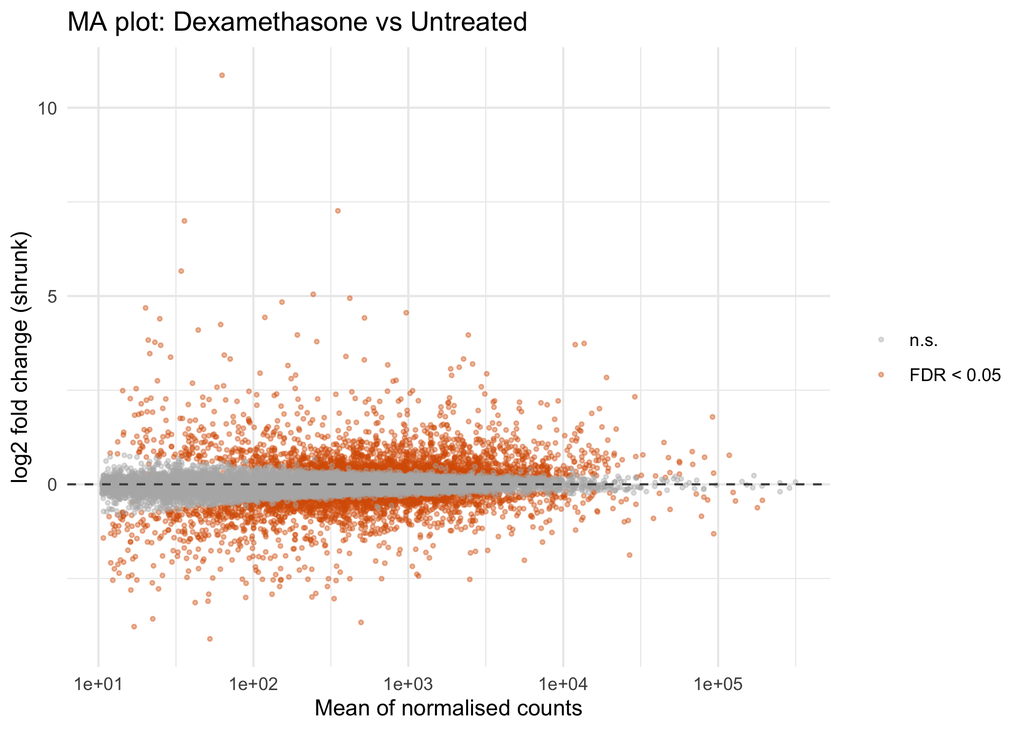

Figure 1

```r
p_ma <- res_df |>
  filter(!is.na(padj)) |>
  mutate(significant = padj < ALPHA) |>
  ggplot(aes(x = baseMean, y = log2FoldChange_shrunk, colour = significant)) +
  geom_point(alpha = 0.4, size = 0.7) +
  geom_hline(yintercept = 0, linetype = "dashed", colour = "grey30") +
  scale_x_log10() +
  scale_colour_manual(values = c(`FALSE` = "grey70", `TRUE` = "#d95f02"),
                      labels = c(`FALSE` = "n.s.", `TRUE` = paste0("FDR < ", ALPHA))) +
  labs(x = "Mean of normalised counts", y = "log2 fold change (shrunk)",
       colour = NULL, title = "MA plot: Dexamethasone vs Untreated") +
  theme_minimal()

p_ma
ggsave(file.path(fig_dir, "ma_plot.png"), p_ma, width = 7, height = 5, dpi = 150)
```

### Volcano plot

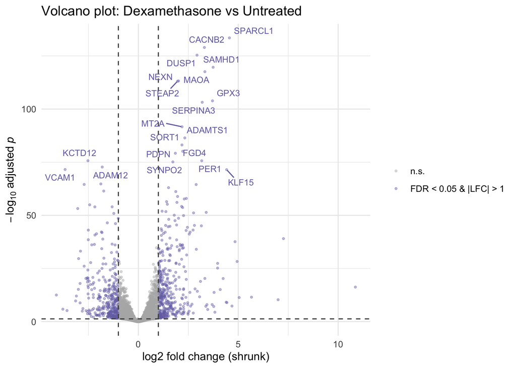

Figure 2

```r
volcano_data <- res_df |>
  filter(!is.na(padj)) |>
  mutate(
    significant = padj < ALPHA & abs(log2FoldChange_shrunk) > 1,
    neg_log10_padj = -log10(padj)
  )

p_volcano <- ggplot(volcano_data,
                    aes(x = log2FoldChange_shrunk, y = neg_log10_padj, colour = significant)) +
  geom_point(alpha = 0.4, size = 0.7) +
  geom_hline(yintercept = -log10(ALPHA), linetype = "dashed", colour = "grey30") +
  geom_vline(xintercept = c(-1, 1), linetype = "dashed", colour = "grey30") +
  geom_text_repel(
    data = slice_head(arrange(volcano_data, padj), n = 20),
    aes(label = label), size = 3, max.overlaps = 20, show.legend = FALSE
  ) +
  scale_colour_manual(values = c(`FALSE` = "grey70", `TRUE` = "#7570b3"),
                      labels = c(`FALSE` = "n.s.", `TRUE` = paste0("FDR < ", ALPHA, " & |LFC| > 1"))) +
  labs(x = "log2 fold change (shrunk)", y = expression(-log[10]~adjusted~italic(p)),
       colour = NULL, title = "Volcano plot: Dexamethasone vs Untreated") +
  theme_minimal()

p_volcano
ggsave(file.path(fig_dir, "volcano_plot.png"), p_volcano, width = 8, height = 6, dpi = 150)
```

### Heatmap of top differentially expressed genes

Variance-stabilised counts, centred per gene so the colour shows deviation from each gene’s mean rather than absolute expression.

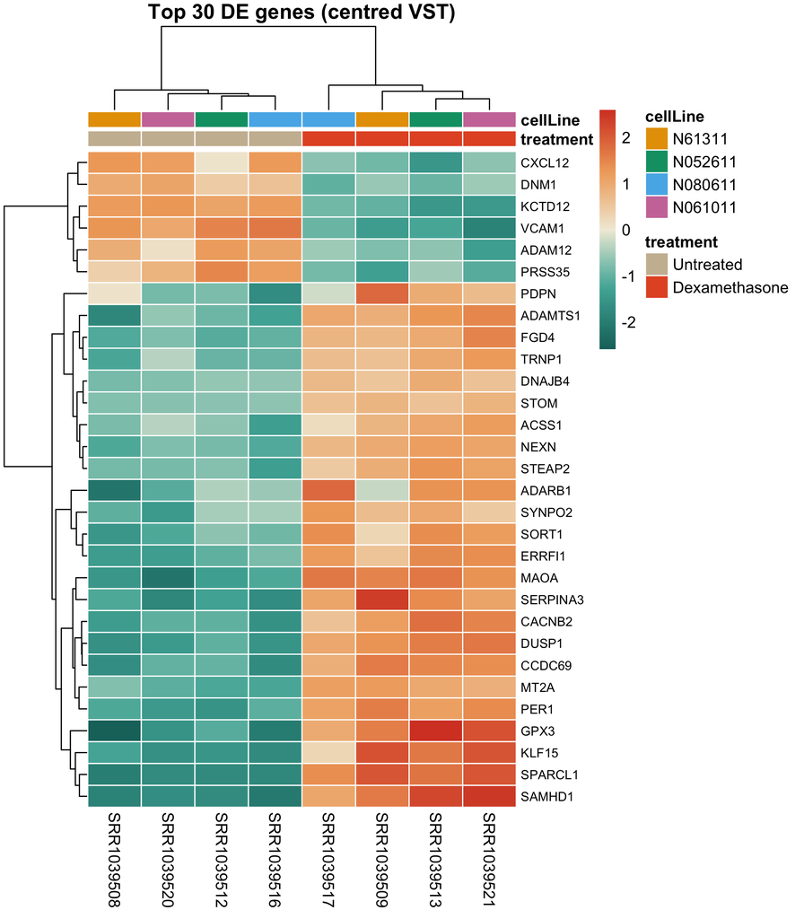

Figure 3

```r
top_genes <- res_df |>
  filter(!is.na(padj)) |>
  slice_head(n = 30)

mat <- assay(vsd)[top_genes$gene_id, ]
mat <- mat - rowMeans(mat)
rownames(mat) <- top_genes$label

annotation_col <- as.data.frame(colData(vsd)[, c("treatment", "cellLine")])

# Summery diverging map for the centred VST values: cool teal (below the gene's
# mean) -> low-chroma cream (at the mean) -> warm coral (above). This keeps the
# diverging rule intact (two hues + a neutral midpoint, no saturated hue at zero)
# while giving a beachier feel than red/blue.
summer_diverging <- colorRampPalette(
  c("#17726B", "#4FB0A5", "#F2ECDB", "#F0A868", "#D6452C")
)(255)

# Symmetric breaks so the neutral cream sits exactly at 0 (= "at the gene's mean").
# Without this, pheatmap stretches the palette across the raw min/max and the
# neutral colour drifts off zero, misreading the diverging scale.
max_abs <- max(abs(mat))
sym_breaks <- seq(-max_abs, max_abs, length.out = length(summer_diverging) + 1)

# Categorical annotation colours. Donor uses an Okabe-Ito-derived set (built to be
# colourblind-safe); treatment keeps the baseline recessive (sand) and lets the
# active condition pop (coral).
ann_colors <- list(
  treatment = c(Untreated = "#CBBBA0", Dexamethasone = "#E4572E"),
  cellLine  = c(N61311 = "#E69F00", N052611 = "#009E73",
                N080611 = "#56B4E9", N061011 = "#CC79A7")
)

heatmap_args <- list(
  mat = mat,
  annotation_col = annotation_col,
  annotation_colors = ann_colors,
  show_colnames = TRUE,
  cluster_cols = TRUE,
  color = summer_diverging,
  breaks = sym_breaks,
  border_color = "white",
  fontsize_row = 8,
  main = "Top 30 DE genes (centred VST)"
)

do.call(pheatmap, heatmap_args)

invisible(do.call(pheatmap, c(
  heatmap_args,
  list(filename = file.path(fig_dir, "heatmap_top_de_genes.png"), width = 8, height = 8)
)))
```

## Export results

```r
results_path <- file.path(repo_root, "results", "deseq2_results.csv")

res_df |>
  select(gene_id, symbol, baseMean, log2FoldChange, log2FoldChange_shrunk,
         lfcSE, stat, pvalue, padj) |>
  write_csv(results_path)

cat(sprintf("Wrote %s rows to %s\n",
            format(nrow(res_df), big.mark = ","), results_path))
```

```
Wrote 15,478 rows to ../results/deseq2_results.csv
```

```r
cat("Figures written to", fig_dir, "\n")
```

```
Figures written to ../results/figures
```